# Factor Analysis applied in Multivariate Regression: Machine Learning’s Perspective

Biostatistics Machine Learning PCA EFA Regression

FA vs. PCA;  
Conducting an Exploratory Factor Analysis Example;  
Factor Score;  
FA applied in Regression;

Hai Nguyen  
September 30, 2022

## Questions

1- What is difference between EFA and PCA?  
2- Is it possible that we can run the regression analysis on factors generating from Factor Analysis?  
3- If so, how can we run it?

The demonstration is to use the dataset [Factor-Hair-Revised.csv](https://www.kaggle.com/ipravin/hair-customer-survey-data-for-100-customers) to build a regression model to predict satisfaction.

## EFA vs. PCA

|  | FA | PCA |
| --- | --- | --- |
| Meaning | A factor (or latent) is a common or underlying element with which several other variables are correlated $X_1 = L_1\times F + \epsilon_1$ $X_2 = L_2\times F + \epsilon_2$ $X_3 = L_3\times F + \epsilon… | A component is a derived new dimension (or variable) so that the derived variables are linearly independent of each other $Y = W_1\times PC_1 + W_2\times PC_2 + ...+ W_{10}\times PC_{10} + C$ where, P… |
| Process | The original variables are defined as the linear combinations of the factors | The components are calculated as the linear combinations of the original variables |
| Objective | FA focuses on explaining the covariances or the correlations between the variables | The aim of PCA is to explain as much of the cumulative variance in the predictors (or variables) as possible |
| Purpose | Factor Analysis is used to understand the underlying ‘cause’ which these factors (latent or constituents) capture much of the information of a set of variables in the dataset data | PCA is used to decompose the data into a smaller number of components and therefore is a type of Singular Value Decomposition (SVD) |
| Interpretation of coefficients | The coefficients (loadings) in the factor analysis express the relationship or association of each variable (X) to the underlying factor (F) | The coefficients indicate which component contributes more to the target variable, Y, as the independent variables are standardized |

## An Example: Data Exploration

```r
prodsurvey <- read_csv("Factor-Hair-Revised.csv")
head(prodsurvey)
```

```
# A tibble: 6 × 13
     ID ProdQual  Ecom TechSup CompRes Adver…¹ ProdL…² Sales…³ ComPr…⁴
  <dbl>    <dbl> <dbl>   <dbl>   <dbl>   <dbl>   <dbl>   <dbl>   <dbl>
1     1      8.5   3.9     2.5     5.9     4.8     4.9     6       6.8
2     2      8.2   2.7     5.1     7.2     3.4     7.9     3.1     5.3
3     3      9.2   3.4     5.6     5.6     5.4     7.4     5.8     4.5
4     4      6.4   3.3     7       3.7     4.7     4.7     4.5     8.8
5     5      9     3.4     5.2     4.6     2.2     6       4.5     6.8
6     6      6.5   2.8     3.1     4.1     4       4.3     3.7     8.5
# … with 4 more variables: WartyClaim <dbl>, OrdBilling <dbl>,
#   DelSpeed <dbl>, Satisfaction <dbl>, and abbreviated variable
#   names ¹Advertising, ²ProdLine, ³SalesFImage, ⁴ComPricing
```

```r
dim(prodsurvey)
```

```
[1] 100  13
```

```r
str(prodsurvey)
```

```
spc_tbl_ [100 × 13] (S3: spec_tbl_df/tbl_df/tbl/data.frame)
 $ ID          : num [1:100] 1 2 3 4 5 6 7 8 9 10 ...
 $ ProdQual    : num [1:100] 8.5 8.2 9.2 6.4 9 6.5 6.9 6.2 5.8 6.4 ...
 $ Ecom        : num [1:100] 3.9 2.7 3.4 3.3 3.4 2.8 3.7 3.3 3.6 4.5 ...
 $ TechSup     : num [1:100] 2.5 5.1 5.6 7 5.2 3.1 5 3.9 5.1 5.1 ...
 $ CompRes     : num [1:100] 5.9 7.2 5.6 3.7 4.6 4.1 2.6 4.8 6.7 6.1 ...
 $ Advertising : num [1:100] 4.8 3.4 5.4 4.7 2.2 4 2.1 4.6 3.7 4.7 ...
 $ ProdLine    : num [1:100] 4.9 7.9 7.4 4.7 6 4.3 2.3 3.6 5.9 5.7 ...
 $ SalesFImage : num [1:100] 6 3.1 5.8 4.5 4.5 3.7 5.4 5.1 5.8 5.7 ...
 $ ComPricing  : num [1:100] 6.8 5.3 4.5 8.8 6.8 8.5 8.9 6.9 9.3 8.4 ...
 $ WartyClaim  : num [1:100] 4.7 5.5 6.2 7 6.1 5.1 4.8 5.4 5.9 5.4 ...
 $ OrdBilling  : num [1:100] 5 3.9 5.4 4.3 4.5 3.6 2.1 4.3 4.4 4.1 ...
 $ DelSpeed    : num [1:100] 3.7 4.9 4.5 3 3.5 3.3 2 3.7 4.6 4.4 ...
 $ Satisfaction: num [1:100] 8.2 5.7 8.9 4.8 7.1 4.7 5.7 6.3 7 5.5 ...
 - attr(*, "spec")=
  .. cols(
  ..   ID = col_double(),
  ..   ProdQual = col_double(),
  ..   Ecom = col_double(),
  ..   TechSup = col_double(),
  ..   CompRes = col_double(),
  ..   Advertising = col_double(),
  ..   ProdLine = col_double(),
  ..   SalesFImage = col_double(),
  ..   ComPricing = col_double(),
  ..   WartyClaim = col_double(),
  ..   OrdBilling = col_double(),
  ..   DelSpeed = col_double(),
  ..   Satisfaction = col_double()
  .. )
 - attr(*, "problems")=<externalptr>
```

```r
names(prodsurvey)
```

```
 [1] "ID"           "ProdQual"     "Ecom"         "TechSup"
 [5] "CompRes"      "Advertising"  "ProdLine"     "SalesFImage"
 [9] "ComPricing"   "WartyClaim"   "OrdBilling"   "DelSpeed"
[13] "Satisfaction"
```

```r
describe(prodsurvey)
```

```
             vars   n  mean    sd median trimmed   mad min   max
ID              1 100 50.50 29.01  50.50   50.50 37.06 1.0 100.0
ProdQual        2 100  7.81  1.40   8.00    7.85  1.78 5.0  10.0
Ecom            3 100  3.67  0.70   3.60    3.63  0.52 2.2   5.7
TechSup         4 100  5.36  1.53   5.40    5.40  1.85 1.3   8.5
CompRes         5 100  5.44  1.21   5.45    5.46  1.26 2.6   7.8
Advertising     6 100  4.01  1.13   4.00    4.00  1.19 1.9   6.5
ProdLine        7 100  5.80  1.32   5.75    5.81  1.56 2.3   8.4
SalesFImage     8 100  5.12  1.07   4.90    5.09  0.89 2.9   8.2
ComPricing      9 100  6.97  1.55   7.10    7.02  1.93 3.7   9.9
WartyClaim     10 100  6.04  0.82   6.10    6.04  0.89 4.1   8.1
OrdBilling     11 100  4.28  0.93   4.40    4.31  0.74 2.0   6.7
DelSpeed       12 100  3.89  0.73   3.90    3.92  0.74 1.6   5.5
Satisfaction   13 100  6.92  1.19   7.05    6.90  1.33 4.7   9.9
             range  skew kurtosis   se
ID            99.0  0.00    -1.24 2.90
ProdQual       5.0 -0.24    -1.17 0.14
Ecom           3.5  0.64     0.57 0.07
TechSup        7.2 -0.20    -0.63 0.15
CompRes        5.2 -0.13    -0.66 0.12
Advertising    4.6  0.04    -0.94 0.11
ProdLine       6.1 -0.09    -0.60 0.13
SalesFImage    5.3  0.37     0.26 0.11
ComPricing     6.2 -0.23    -0.96 0.15
WartyClaim     4.0  0.01    -0.53 0.08
OrdBilling     4.7 -0.32     0.11 0.09
DelSpeed       3.9 -0.45     0.09 0.07
Satisfaction   5.2  0.08    -0.86 0.12
```

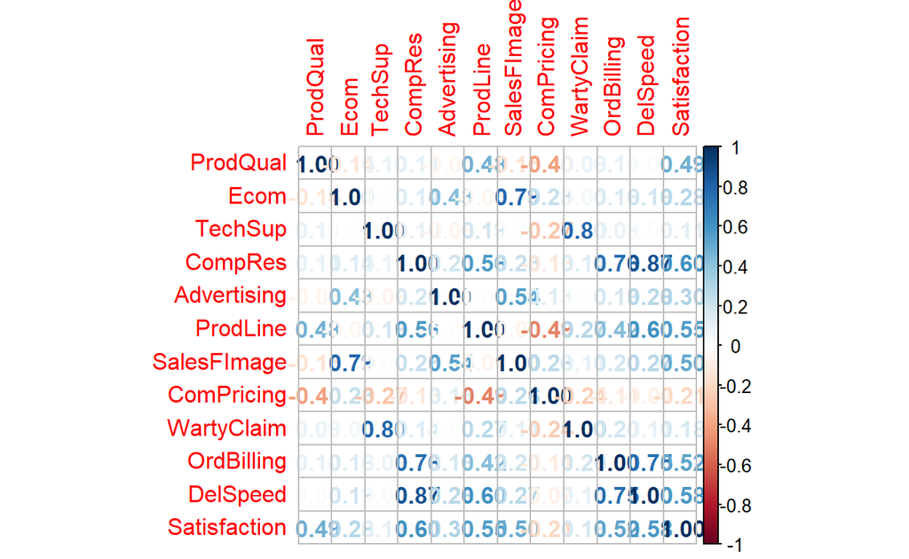

```r
datamatrix1 <- cor(prodsurvey[,-1])
corrplot(datamatrix1, method="number")
```

As we can see from the above correlation matrix:

1. Complaint resolution (`CompRes`) and delivery speed (`DelSpeed`) are highly correlated
2. Order billing (`OrdBilling`) and `CompRes` are highly correlated
3. `WartyClaim` and `TechSupport` are highly correlated
4. `OrdBilling` and `DelSpeed` are highly correlated
5. e-commerce (`Ecom`) and sales force image (`SalesFImage`) are highly correlated

```r
pcor(prodsurvey[,-1], method="pearson")
```

```
$estimate
                 ProdQual          Ecom      TechSup      CompRes
ProdQual      1.000000000  0.1549597037  0.002424222 -0.056354142
Ecom          0.154959704  1.0000000000  0.082359000 -0.033513777
TechSup       0.002424222  0.0823590001  1.000000000  0.143603415
CompRes      -0.056354142 -0.0335137768  0.143603415  1.000000000
Advertising   0.112376746 -0.0002972504 -0.059300254 -0.064806093
ProdLine      0.281144724  0.1538660545 -0.125349050  0.020305650
SalesFImage  -0.376228551  0.7321011890 -0.093310796 -0.022150933
ComPricing   -0.014021386  0.0149131857 -0.132972485 -0.004487151
WartyClaim   -0.042752416 -0.1232553822  0.787729606 -0.109686211
OrdBilling    0.054523215  0.1546990521 -0.165914724  0.288344382
DelSpeed     -0.335084210 -0.0083917930 -0.021914916  0.528932328
Satisfaction  0.607438787 -0.3308440834  0.055111867  0.172416347
               Advertising    ProdLine  SalesFImage   ComPricing
ProdQual      0.1123767461  0.28114472 -0.376228551 -0.014021386
Ecom         -0.0002972504  0.15386605  0.732101189  0.014913186
TechSup      -0.0593002540 -0.12534905 -0.093310796 -0.132972485
CompRes      -0.0648060931  0.02030565 -0.022150933 -0.004487151
Advertising   1.0000000000 -0.13192319  0.262879343 -0.063298038
ProdLine     -0.1319231866  1.00000000 -0.230170570 -0.361757904
SalesFImage   0.2628793429 -0.23017057  1.000000000  0.126612489
ComPricing   -0.0632980381 -0.36175790  0.126612489  1.000000000
WartyClaim    0.0275909587  0.25718360  0.189300271  0.020351554
OrdBilling   -0.0326580430 -0.28098068 -0.182359301 -0.086500869
DelSpeed      0.2046544064  0.50189505  0.005889925  0.190437993
Satisfaction -0.0449735411  0.18325156  0.660251850 -0.087467711
              WartyClaim  OrdBilling     DelSpeed Satisfaction
ProdQual     -0.04275242  0.05452322 -0.335084210   0.60743879
Ecom         -0.12325538  0.15469905 -0.008391793  -0.33084408
TechSup       0.78772961 -0.16591472 -0.021914916   0.05511187
CompRes      -0.10968621  0.28834438  0.528932328   0.17241635
Advertising   0.02759096 -0.03265804  0.204654406  -0.04497354
ProdLine      0.25718360 -0.28098068  0.501895051   0.18325156
SalesFImage   0.18930027 -0.18235930  0.005889925   0.66025185
ComPricing    0.02035155 -0.08650087  0.190437993  -0.08746771
WartyClaim    1.00000000  0.25984451 -0.091649002  -0.08868071
OrdBilling    0.25984451  1.00000000  0.350530212   0.14880055
DelSpeed     -0.09164900  0.35053021  1.000000000   0.08955614
Satisfaction -0.08868071  0.14880055  0.089556143   1.00000000
```

[output cut: 76 more lines]

```
SalesFImage   1.8084929 -1.7398559  0.05525335    8.2467993
ComPricing    0.1909540 -0.8145030  1.81976992   -0.8236767
WartyClaim    0.0000000  2.5242649 -0.86337748   -0.8351894
OrdBilling    2.5242649  0.0000000  3.51103503    1.4115877
DelSpeed     -0.8633775  3.5110350  0.00000000    0.8435005
Satisfaction -0.8351894  1.4115877  0.84350046    0.0000000

$n
[1] 100

$gp
[1] 10

$method
[1] "pearson"
```

- We can see that there is a high degree of collinearity between the independent variables.

## Multiple Linear Regression

```r
model1 <- lm(Satisfaction ~ ., prodsurvey[,-1])
summary(model1)
```

```
Call:
lm(formula = Satisfaction ~ ., data = prodsurvey[, -1])

Residuals:
     Min       1Q   Median       3Q      Max
-1.43005 -0.31165  0.07621  0.37190  0.90120

Coefficients:
            Estimate Std. Error t value Pr(>|t|)
(Intercept) -0.66961    0.81233  -0.824  0.41199
ProdQual     0.37137    0.05177   7.173 2.18e-10 ***
Ecom        -0.44056    0.13396  -3.289  0.00145 **
TechSup      0.03299    0.06372   0.518  0.60591
CompRes      0.16703    0.10173   1.642  0.10416
Advertising -0.02602    0.06161  -0.422  0.67382
ProdLine     0.14034    0.08025   1.749  0.08384 .
SalesFImage  0.80611    0.09775   8.247 1.45e-12 ***
ComPricing  -0.03853    0.04677  -0.824  0.41235
WartyClaim  -0.10298    0.12330  -0.835  0.40587
OrdBilling   0.14635    0.10367   1.412  0.16160
DelSpeed     0.16570    0.19644   0.844  0.40124
---
Signif. codes:  0 '***' 0.001 '**' 0.01 '*' 0.05 '.' 0.1 ' ' 1

Residual standard error: 0.5623 on 88 degrees of freedom
Multiple R-squared:  0.8021,    Adjusted R-squared:  0.7774
F-statistic: 32.43 on 11 and 88 DF,  p-value: < 2.2e-16
```

- As in our model the adjusted R-squared: 0.7774, meaning that independent variables explain 78% of the variance of the dependent variable, only 3 variables are significant out of 11 independent variables.
- The p-value of the F-statistic is less than 0.05 (level of Significance), which means our model is significant. This means that, at least, one of the predictor variables is significantly related to the outcome variable.
- Our model equation can be written as:  
  Satisfaction = -0.66 + 0.37 x `ProdQual` -0.44 x `Ecom` + 0.034 x `TechSup` + 0.16 x `CompRes` -0.02 x `Advertising` + 0.14 x `ProdLine` + 0.80 x `SalesFImage` - 0.038 x `CompPricing` - 0.10 x `WartyClaim` + 0.14 x `OrdBilling` + 0.16 x `DelSpeed`

## Variable Inflation Factor (VIF)

```r
vif(model1)
```

```
   ProdQual        Ecom     TechSup     CompRes Advertising
   1.635797    2.756694    2.976796    4.730448    1.508933
   ProdLine SalesFImage  ComPricing  WartyClaim  OrdBilling
   3.488185    3.439420    1.635000    3.198337    2.902999
   DelSpeed
   6.516014
```

## Factor Analysis

```r
X <- prodsurvey[,-c(1,13)]
y <- prodsurvey[,13]
```

Let’s check the factorability of the variables in the dataset: perform the Kaiser-Meyer-Olkin (KMO) Test.

```r
datamatrix2 <- cor(X)
KMO(r=datamatrix2)
```

```
Kaiser-Meyer-Olkin factor adequacy
Call: KMO(r = datamatrix2)
Overall MSA =  0.65
MSA for each item =
   ProdQual        Ecom     TechSup     CompRes Advertising
       0.51        0.63        0.52        0.79        0.78
   ProdLine SalesFImage  ComPricing  WartyClaim  OrdBilling
       0.62        0.62        0.75        0.51        0.76
   DelSpeed
       0.67
```

- MSA (measure of sampling adequacy) > 0.5, we can run Factor Analysis on this data.

```r
print(cortest.bartlett(datamatrix2, nrow(prodsurvey[,-1])))
```

```
$chisq
[1] 619.2726

$p.value
[1] 1.79337e-96

$df
[1] 55
```

- The approximate of Chi-square is 619.27 with 55 degrees of freedom, which is significant at 0.05 Level of significance.

Hence Factor Analysis is considered as an appropriate technique for further analysis of the data.

### Find the optimal clusters

Plotting the eigenvalues from our factor analysis (whether it’s based on principal axis or principal components extraction), a parallel analysis involves generating random correlation matrices and after factor analyzing them, comparing the resulting eigenvalues to the eigenvalues of the observed data. The idea behind this method is thatobserved eigenvalues that are higher than their corresponding random eigenvalues are more likely to be from “meaningful factors” than observed eigenvalues that are below their corresponding random eigenvalue.

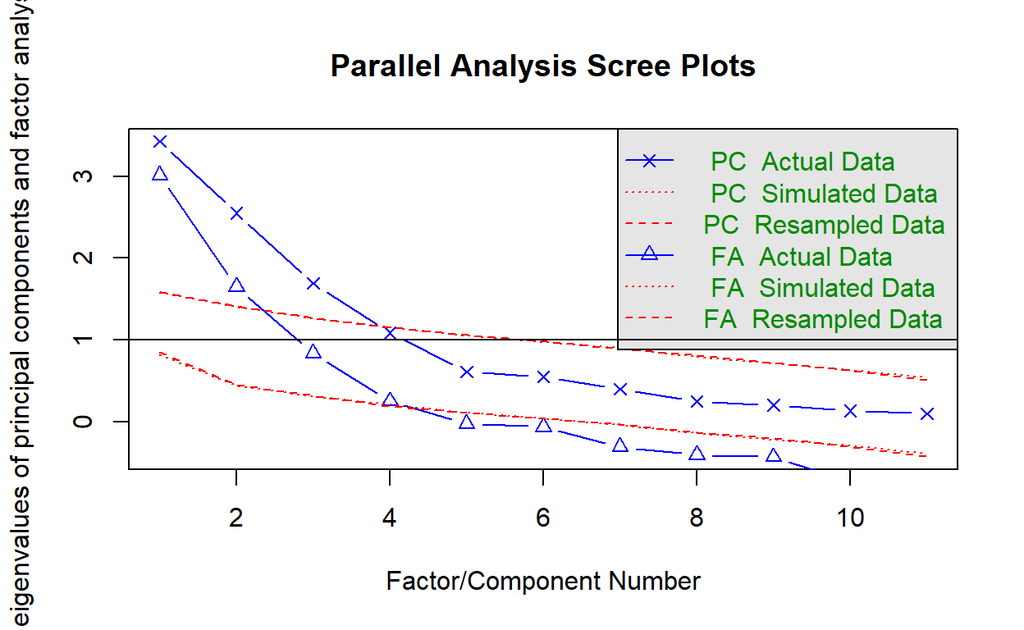

```
Parallel analysis suggests that the number of factors =  3  and the number of components =  3
```

```r
parallel <- fa.parallel(X)
```

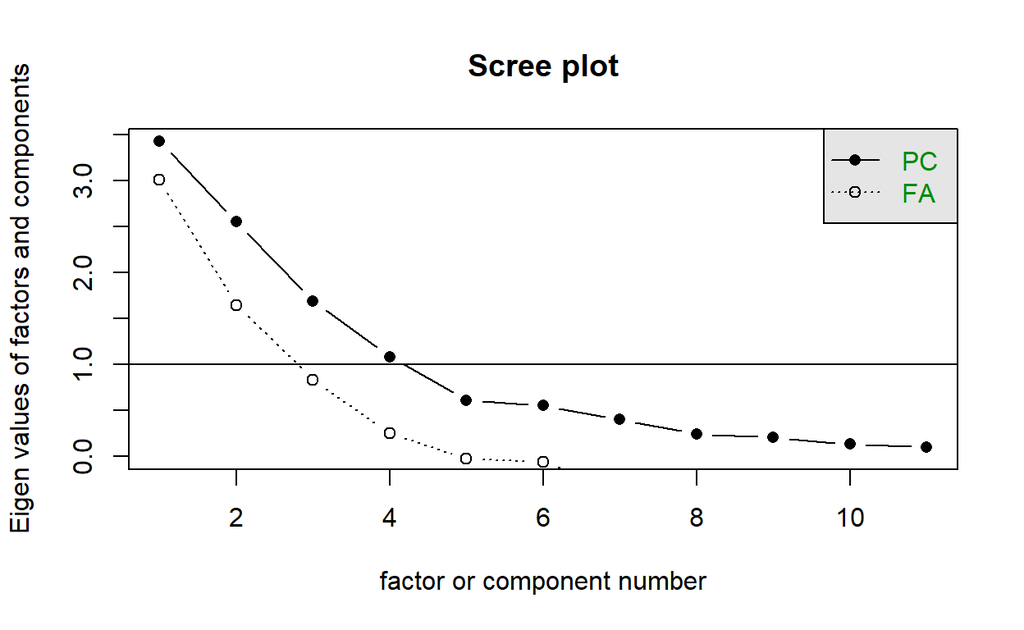

```r
# other option of scree plot
scree(X)
```

Selection of factors from the scree plot can be based on:

1. Kaiser-Guttman normalization rule says that we should choose all factors with an eigenvalue greater than 1.
2. Bend elbow rule

- The scree plot graphs the Eigenvalue against each factor. We can see from the graph that after factor 4 there is a sharp change in the curvature of the scree plot. This shows that after factor 4 the total variance accounts for smaller amounts.

```r
ev <- eigen(cor(X))
ev$values
```

```
 [1] 3.42697133 2.55089671 1.69097648 1.08655606 0.60942409 0.55188378
 [7] 0.40151815 0.24695154 0.20355327 0.13284158 0.09842702
```

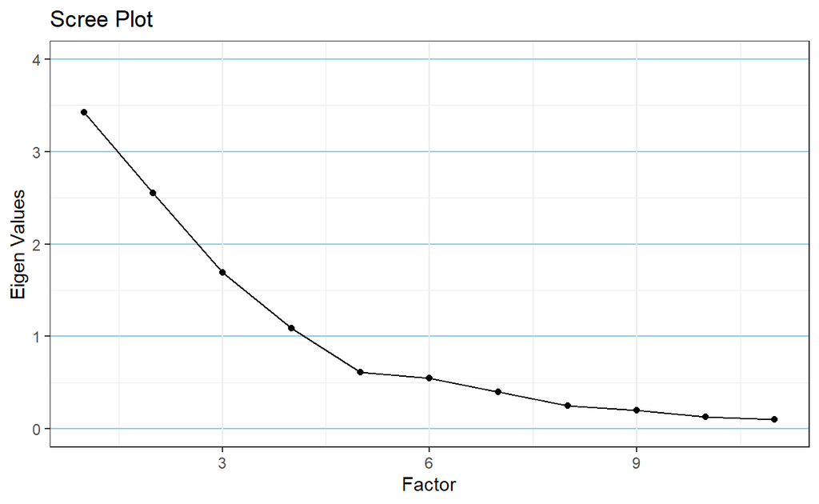

```r
Factor <- rep(1:11)
Eigen_Values <- ev$values
Scree <- data.frame(Factor, Eigen_Values)

ggplot(data = Scree, mapping = aes(x = Factor, y = Eigen_Values)) +
  geom_point() +
  geom_line() +
  scale_y_continuous(name = "Eigen Values", limits = c(0,4)) +
  theme_bw() +
  theme(panel.grid.major.y = element_line(color = "skyblue")) +
  ggtitle("Scree Plot")
```

So as per the elbow or Kaiser-Guttman normalization rule, we are good to go ahead with 4 factors.

### Conducting the Factor Analysis

1. Factor analysis using fa method:

```r
fa.none <-  fa(r=X,
              nfactors = 4,
#              covar = FALSE, SMC = TRUE,
              fm="pa", # type of factor analysis we want to use (“pa” is principal axis factoring)
              max.iter=100, # (50 is the default, but we have changed it to 100
              rotate="none") # none rotation
print(fa.none)
```

```
Factor Analysis using method =  pa
Call: fa(r = X, nfactors = 4, rotate = "none", max.iter = 100, fm = "pa")
Standardized loadings (pattern matrix) based upon correlation matrix
              PA1   PA2   PA3   PA4   h2    u2 com
ProdQual     0.20 -0.41 -0.06  0.46 0.42 0.576 2.4
Ecom         0.29  0.66  0.27  0.22 0.64 0.362 2.0
TechSup      0.28 -0.38  0.74 -0.17 0.79 0.205 1.9
CompRes      0.86  0.01 -0.26 -0.18 0.84 0.157 1.3
Advertising  0.29  0.46  0.08  0.13 0.31 0.686 1.9
ProdLine     0.69 -0.45 -0.14  0.31 0.80 0.200 2.3
SalesFImage  0.39  0.80  0.35  0.25 0.98 0.021 2.1
ComPricing  -0.23  0.55 -0.04 -0.29 0.44 0.557 1.9
WartyClaim   0.38 -0.32  0.74 -0.15 0.81 0.186 2.0
OrdBilling   0.75  0.02 -0.18 -0.18 0.62 0.378 1.2
DelSpeed     0.90  0.10 -0.30 -0.20 0.94 0.058 1.4

                       PA1  PA2  PA3  PA4
SS loadings           3.21 2.22 1.50 0.68
Proportion Var        0.29 0.20 0.14 0.06
Cumulative Var        0.29 0.49 0.63 0.69
Proportion Explained  0.42 0.29 0.20 0.09
Cumulative Proportion 0.42 0.71 0.91 1.00

Mean item complexity =  1.9
Test of the hypothesis that 4 factors are sufficient.

The degrees of freedom for the null model are  55  and the objective function was  6.55 with Chi Square of  619.27
The degrees of freedom for the model are 17  and the objective function was  0.33

The root mean square of the residuals (RMSR) is  0.02
The df corrected root mean square of the residuals is  0.03

The harmonic number of observations is  100 with the empirical chi square  3.19  with prob <  1
The total number of observations was  100  with Likelihood Chi Square =  30.27  with prob <  0.024

Tucker Lewis Index of factoring reliability =  0.921
RMSEA index =  0.088  and the 90 % confidence intervals are  0.032 0.139
BIC =  -48.01
Fit based upon off diagonal values = 1
Measures of factor score adequacy
                                                   PA1  PA2  PA3  PA4
Correlation of (regression) scores with factors   0.98 0.97 0.95 0.88
Multiple R square of scores with factors          0.96 0.95 0.91 0.78
Minimum correlation of possible factor scores     0.92 0.90 0.82 0.56
```

2. Factor analysis using the factanal method:

```r
factanal.none <- factanal(X, factors=4, scores = c("regression"), rotation = "none")
print(factanal.none)
```

```
Call:
factanal(x = X, factors = 4, scores = c("regression"), rotation = "none")

Uniquenesses:
   ProdQual        Ecom     TechSup     CompRes Advertising
      0.682       0.360       0.228       0.178       0.679
   ProdLine SalesFImage  ComPricing  WartyClaim  OrdBilling
      0.005       0.017       0.636       0.163       0.347
   DelSpeed
      0.076

Loadings:
            Factor1 Factor2 Factor3 Factor4
ProdQual     0.467  -0.148  -0.229  -0.159
Ecom                 0.791
TechSup      0.198          -0.482   0.707
CompRes      0.589   0.316   0.535   0.300
Advertising          0.556   0.110
ProdLine     0.997
SalesFImage          0.987
ComPricing  -0.491   0.252   0.238
WartyClaim   0.279   0.124  -0.487   0.712
OrdBilling   0.452   0.275   0.493   0.360
DelSpeed     0.629   0.364   0.582   0.241

               Factor1 Factor2 Factor3 Factor4
SS loadings      2.522   2.316   1.469   1.322
Proportion Var   0.229   0.211   0.134   0.120
Cumulative Var   0.229   0.440   0.573   0.694

Test of the hypothesis that 4 factors are sufficient.
The chi square statistic is 24.26 on 17 degrees of freedom.
The p-value is 0.113
```

```r
factanal.var <- factanal(X, factors=4, scores = c("regression"), rotation = "varimax")
print(factanal.var)
```

```
Call:
factanal(x = X, factors = 4, scores = c("regression"), rotation = "varimax")

Uniquenesses:
   ProdQual        Ecom     TechSup     CompRes Advertising
      0.682       0.360       0.228       0.178       0.679
   ProdLine SalesFImage  ComPricing  WartyClaim  OrdBilling
      0.005       0.017       0.636       0.163       0.347
   DelSpeed
      0.076

Loadings:
            Factor1 Factor2 Factor3 Factor4
ProdQual                             0.557
Ecom                 0.793
TechSup                      0.872   0.102
CompRes      0.884   0.142           0.135
Advertising  0.190   0.521          -0.110
ProdLine     0.502           0.104   0.856
SalesFImage  0.119   0.974          -0.130
ComPricing           0.225  -0.216  -0.514
WartyClaim                   0.894   0.158
OrdBilling   0.794   0.101   0.105
DelSpeed     0.928   0.189           0.164

               Factor1 Factor2 Factor3 Factor4
SS loadings      2.592   1.977   1.638   1.423
Proportion Var   0.236   0.180   0.149   0.129
Cumulative Var   0.236   0.415   0.564   0.694

Test of the hypothesis that 4 factors are sufficient.
The chi square statistic is 24.26 on 17 degrees of freedom.
The p-value is 0.113
```

### Graph Factor Loading Matrices

Factor analysis results are typically interpreted in terms of the major loadings on each factor. These structures may be represented an “interpretable” solution as a table of loadings or graphically, where all loadings with an absolute value $\rightarrow$ some cut point are represented as an edge (path).

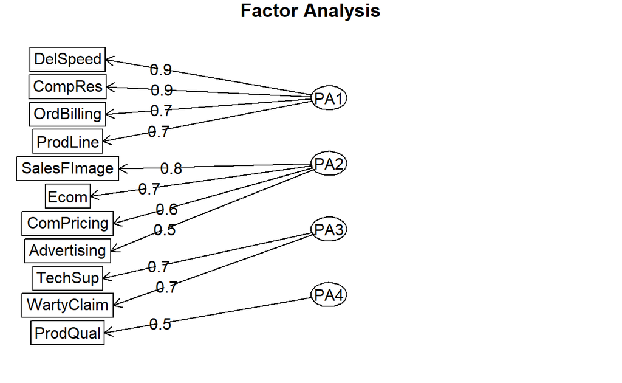

```r
fa.diagram(fa.none)
```

- The first 4 factors have an Eigenvalue >1 and which explains almost 69% of the variance. We can effectively reduce dimensionality from 11 to 4 while only losing about 31% of the variance.
- Factor 1 accounts for 29.20% of the variance; Factor 2 accounts for 20.20% of the variance; Factor 3 accounts for 13.60% of the variance; Factor 4 accounts for 6% of the variance. All the 4 factors together explain for 69% of the variance in performance.

```r
fa.var <-  fa(r=X,
              nfactors = 4,
#              covar = FALSE, SMC = TRUE,
              fm="pa", # type of factor analysis we want to use (“pa” is principal axis factoring)
              max.iter=100, # (50 is the default, but we have changed it to 100
              rotate="varimax") # none rotation
print(fa.var)
```

```
Factor Analysis using method =  pa
Call: fa(r = X, nfactors = 4, rotate = "varimax", max.iter = 100, fm = "pa")
Standardized loadings (pattern matrix) based upon correlation matrix
              PA1   PA2   PA3   PA4   h2    u2 com
ProdQual     0.02 -0.07  0.02  0.65 0.42 0.576 1.0
Ecom         0.07  0.79  0.03 -0.11 0.64 0.362 1.1
TechSup      0.02 -0.03  0.88  0.12 0.79 0.205 1.0
CompRes      0.90  0.13  0.05  0.13 0.84 0.157 1.1
Advertising  0.17  0.53 -0.04 -0.06 0.31 0.686 1.2
ProdLine     0.53 -0.04  0.13  0.71 0.80 0.200 1.9
SalesFImage  0.12  0.97  0.06 -0.13 0.98 0.021 1.1
ComPricing  -0.08  0.21 -0.21 -0.59 0.44 0.557 1.6
WartyClaim   0.10  0.06  0.89  0.13 0.81 0.186 1.1
OrdBilling   0.77  0.13  0.09  0.09 0.62 0.378 1.1
DelSpeed     0.95  0.19  0.00  0.09 0.94 0.058 1.1

                       PA1  PA2  PA3  PA4
SS loadings           2.63 1.97 1.64 1.37
Proportion Var        0.24 0.18 0.15 0.12
Cumulative Var        0.24 0.42 0.57 0.69
Proportion Explained  0.35 0.26 0.22 0.18
Cumulative Proportion 0.35 0.60 0.82 1.00

Mean item complexity =  1.2
Test of the hypothesis that 4 factors are sufficient.

The degrees of freedom for the null model are  55  and the objective function was  6.55 with Chi Square of  619.27
The degrees of freedom for the model are 17  and the objective function was  0.33

The root mean square of the residuals (RMSR) is  0.02
The df corrected root mean square of the residuals is  0.03

The harmonic number of observations is  100 with the empirical chi square  3.19  with prob <  1
The total number of observations was  100  with Likelihood Chi Square =  30.27  with prob <  0.024

Tucker Lewis Index of factoring reliability =  0.921
RMSEA index =  0.088  and the 90 % confidence intervals are  0.032 0.139
BIC =  -48.01
Fit based upon off diagonal values = 1
Measures of factor score adequacy
                                                   PA1  PA2  PA3  PA4
Correlation of (regression) scores with factors   0.98 0.99 0.94 0.88
Multiple R square of scores with factors          0.96 0.97 0.88 0.78
Minimum correlation of possible factor scores     0.93 0.94 0.77 0.55
```

```r
fa.var$loadings
```

```
Loadings:
            PA1    PA2    PA3    PA4
ProdQual                          0.647
Ecom                0.787        -0.113
TechSup                    0.883  0.116
CompRes      0.898  0.130         0.132
Advertising  0.166  0.530
ProdLine     0.525         0.127  0.712
SalesFImage  0.115  0.971        -0.135
ComPricing          0.213 -0.209 -0.590
WartyClaim   0.103         0.885  0.128
OrdBilling   0.768  0.127
DelSpeed     0.949  0.185

                 PA1   PA2   PA3   PA4
SS loadings    2.635 1.967 1.641 1.371
Proportion Var 0.240 0.179 0.149 0.125
Cumulative Var 0.240 0.418 0.568 0.692
```

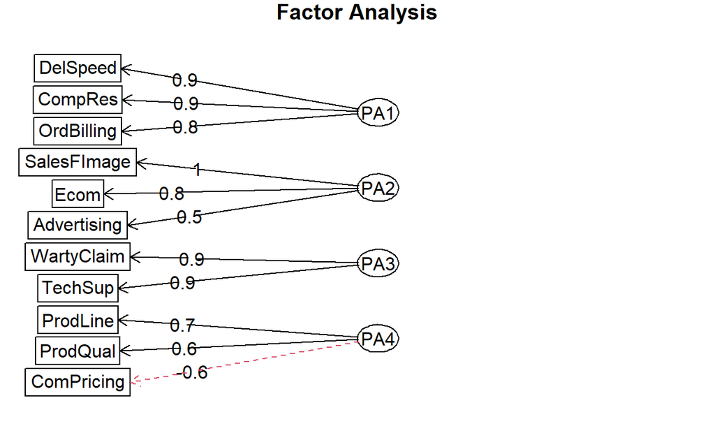

```r
fa.diagram(fa.var)
```

- The red dotted line means that Competitive Pricing marginally falls under the PA4 bucket and the loading are negative.

### Labeling and interpretation of the factors

| Factors | Variables | Label | Short Interpretaation |
| --- | --- | --- | --- |
| PA1 | DelSpeed, CompRes, OrdBilling | Purchase | All the items are related to purchasing the product; from placing order to billing and getting it delivered. |
| PA2 | SalesFImage, Ecom, Advertising | Marketing | In this factors the item are related to marketing processes like the image of sales force and spending on adverstising |
| PA3 | WartyClaim, TechSup | Post Purchase | Post purchase activities are included in this factor; like warranty claims and technical support. |
| PA4 | ProdLine, ProdQual, CompPricing | Product Position | Product positioning related items are grouped in this factor. |

### Scores for all the rows

```r
head(fa.var$scores)
```

```
            PA1        PA2          PA3         PA4
[1,] -0.1338871  0.9175166 -1.719604873  0.09135411
[2,]  1.6297604 -2.0090053 -0.596361722  0.65808192
[3,]  0.3637658  0.8361736  0.002979966  1.37548765
[4,] -1.2225230 -0.5491336  1.245473305 -0.64421384
[5,] -0.4854209 -0.4276223 -0.026980304  0.47360747
[6,] -0.5950924 -1.3035333 -1.183019401 -0.95913571
```

```r
#fa.var$scores # for 100 observations
```

## Regression analysis using the factors scores as the independent variable

```r
regdata <- cbind(prodsurvey["Satisfaction"], fa.var$scores)

#Labeling the data
names(regdata) <- c("Satisfaction", "Purchase", "Marketing",
                    "Post_purchase", "Prod_positioning")
head(regdata)
```

```
  Satisfaction   Purchase  Marketing Post_purchase Prod_positioning
1          8.2 -0.1338871  0.9175166  -1.719604873       0.09135411
2          5.7  1.6297604 -2.0090053  -0.596361722       0.65808192
3          8.9  0.3637658  0.8361736   0.002979966       1.37548765
4          4.8 -1.2225230 -0.5491336   1.245473305      -0.64421384
5          7.1 -0.4854209 -0.4276223  -0.026980304       0.47360747
6          4.7 -0.5950924 -1.3035333  -1.183019401      -0.95913571
```

### Splitting the data to train and test set

```r
#Splitting the data 70:30
#Random number generator, set seed.
set.seed(100)
indices= sample(1:nrow(regdata), 0.7*nrow(regdata))
train=regdata[indices,]
test = regdata[-indices,]
```

### Regression Model using train data

```r
model.fa.score = lm(Satisfaction~., train)
summary(model.fa.score)
```

```
Call:
lm(formula = Satisfaction ~ ., data = train)

Residuals:
     Min       1Q   Median       3Q      Max
-1.76280 -0.48717  0.06799  0.46459  1.24022

Coefficients:
                 Estimate Std. Error t value Pr(>|t|)
(Intercept)       6.91852    0.08068  85.757  < 2e-16 ***
Purchase          0.50230    0.07641   6.574 9.74e-09 ***
Marketing         0.75488    0.08390   8.998 5.00e-13 ***
Post_purchase     0.08755    0.08216   1.066    0.291
Prod_positioning  0.58074    0.08781   6.614 8.30e-09 ***
---
Signif. codes:  0 '***' 0.001 '**' 0.01 '*' 0.05 '.' 0.1 ' ' 1

Residual standard error: 0.6629 on 65 degrees of freedom
Multiple R-squared:  0.7261,    Adjusted R-squared:  0.7093
F-statistic: 43.08 on 4 and 65 DF,  p-value: < 2.2e-16
```

### Check vif

```r
vif(model.fa.score)
```

```
        Purchase        Marketing    Post_purchase Prod_positioning
        1.009648         1.008235         1.015126         1.024050
```

- As per the VIF values, we don’t have multicollinearity in the model

### Check prediction of the model in the test dataset

```r
#Model Performance metrics:
pred_test <- predict(model.fa.score, newdata = test, type = "response")
pred_test
```

```
       6        8       11       13       17       19       26
4.975008 5.908267 6.951629 8.677431 6.613838 6.963113 6.313513
      33       34       35       37       40       42       44
6.141338 6.158993 7.415742 6.589746 6.858206 7.133989 8.533080
      49       50       53       56       57       60       65
8.765145 8.078744 7.395438 7.468360 8.744402 6.276660 5.936570
      67       71       73       75       80       96       97
6.650322 8.299545 7.685564 7.330191 6.719528 7.540233 6.143172
      99      100
8.084583 5.799897
```

```r
#Find MSE and MAPE scores:
#MSE/ MAPE of Model1
test$Satisfaction_Predicted <- pred_test
head(test[c("Satisfaction","Satisfaction_Predicted")], 10)
```

```
   Satisfaction Satisfaction_Predicted
6           4.7               4.975008
8           6.3               5.908267
11          7.4               6.951629
13          8.4               8.677431
17          6.4               6.613838
19          6.8               6.963113
26          6.6               6.313513
33          5.4               6.141338
34          7.3               6.158993
35          6.3               7.415742
```

```r
test_r2 <- cor(test$Satisfaction, test$Satisfaction_Predicted) ^2

mse_test <- mse(test$Satisfaction, pred_test)
rmse_test <- sqrt(mse(test$Satisfaction, pred_test))
mape_test <- mape(test$Satisfaction, pred_test)
model_metrics <- cbind(mse_test,rmse_test,mape_test,test_r2)
print(model_metrics, 3)
```

```
     mse_test rmse_test mape_test test_r2
[1,]    0.551     0.742    0.0875   0.554
```

As the feature `Post_purchase` is not significant so we will drop this feature and then let’s run the regression model again.

```r
##Regression model without post_purchase:
model2 <- lm(Satisfaction ~ Purchase+ Marketing+
                Prod_positioning, data= train)
summary(model2)
```

```
Call:
lm(formula = Satisfaction ~ Purchase + Marketing + Prod_positioning,
    data = train)

Residuals:
    Min      1Q  Median      3Q     Max
-1.7268 -0.5036  0.1117  0.4408  1.2962

Coefficients:
                 Estimate Std. Error t value Pr(>|t|)
(Intercept)       6.92158    0.08071  85.761  < 2e-16 ***
Purchase          0.49779    0.07637   6.518 1.15e-08 ***
Marketing         0.75870    0.08391   9.042 3.66e-13 ***
Prod_positioning  0.59084    0.08739   6.761 4.30e-09 ***
---
Signif. codes:  0 '***' 0.001 '**' 0.01 '*' 0.05 '.' 0.1 ' ' 1

Residual standard error: 0.6636 on 66 degrees of freedom
Multiple R-squared:  0.7213,    Adjusted R-squared:  0.7087
F-statistic: 56.95 on 3 and 66 DF,  p-value: < 2.2e-16
```

```r
pred_test2 <- predict(model2, newdata = test, type = "response")
pred_test2
```

```
       6        8       11       13       17       19       26
5.069667 5.958765 7.001694 8.695630 6.521440 6.994018 6.249667
      33       34       35       37       40       42       44
6.123357 6.132165 7.415882 6.566556 6.964570 7.233376 8.424720
      49       50       53       56       57       60       65
8.853060 8.177009 7.413693 7.404078 8.746511 6.215816 5.893515
      67       71       73       75       80       96       97
6.476465 8.227837 7.839941 7.354907 6.734279 7.559995 6.293774
      99      100
8.083909 5.832094
```

```r
test$Satisfaction_Predicted2 <- pred_test2
head(test[c(1,7)], 10)
```

```
   Satisfaction Satisfaction_Predicted2
6           4.7                5.069667
8           6.3                5.958765
11          7.4                7.001694
13          8.4                8.695630
17          6.4                6.521440
19          6.8                6.994018
26          6.6                6.249667
33          5.4                6.123357
34          7.3                6.132165
35          6.3                7.415882
```

```r
test_r22 <- cor(test$Satisfaction, test$Satisfaction_Predicted2) ^2
mse_test2 <- mse(test$Satisfaction, pred_test2)
rmse_test2 <- sqrt(mse(test$Satisfaction, pred_test2))
mape_test2 <- mape(test$Satisfaction, pred_test2)

model2_metrics <- cbind(mse_test2,rmse_test2,mape_test2,test_r22)
model2_metrics
```

```
     mse_test2 rmse_test2 mape_test2  test_r22
[1,] 0.5446039  0.7379728 0.08490197 0.5595099
```

```r
Overall <- rbind(model_metrics,model2_metrics)
row.names(Overall) <- c("Test1", "Test2")
colnames(Overall) <- c("MSE", "RMSE", "MAPE", "R-squared")
print(Overall,3)
```

```
        MSE  RMSE   MAPE R-squared
Test1 0.551 0.742 0.0875     0.554
Test2 0.545 0.738 0.0849     0.560
```

## Conclusion

We saw how Factor Analysis can be used to reduce the dimensionality of a dataset and then we used multiple linear regression on the dimensionally reduced columns/Features for further analysis/predictions.

## Further Reading

- [A repost from Haibiostat’s rpubs](https://rpubs.com/Haibiostat/FAinMReg)
- [AnalytixLabs](https://www.analytixlabs.co.in/blog/factor-analysis-vs-pca/#:~:text=PCA%20is%20used%20to%20decompose,variables%20in%20the%20dataset%20data.)
- Jay Narayan, [Multiple Linear Regression & Factor Analysis in R](https://medium.com/analytics-vidhya/multiple-linear-regression-factor-analysis-in-r-35a26a2575cc), May 28, 2019
- Rachael Smyth and Andrew Johnson, [Factor Analysis](https://www.uwo.ca/fhs/tc/labs/10.FactorAnalysis.pdf)
- Sreenu Konda, Lecture on Factor Analysis, Bistatistics, SPH, UIC, Spring 2020